# csir_ipython

## Adding YouYube videos

- You can also add rich media like YouTube Videos into the notebook

```python
#you can embed the HTML or programatically add it.
from IPython.display import YouTubeVideo
YouTubeVideo('iwVvqwLDsJo', width=1000, height=600)
```

[video not shown]

## Plotting with Matplotlib

- Matplotlib is a Python 2D plotting library
- Produces publication quality figures
- Variety of hardcopy formats and interactive environments across platforms
- Matplotlib can be used in
  - Python scripts,
  - The Python and IPython shell,
  - Web application servers,
  - Graphical user interface toolkits.

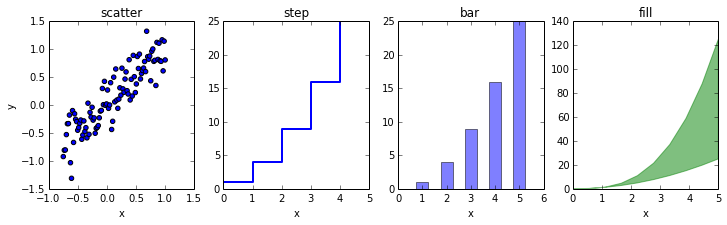

```python
from matplotlib.pylab import xkcd
from numpy import *

#generate some data
n = array([0,1,2,3,4,5])
xx = np.linspace(-0.75, 1., 100)
x = linspace(0, 5, 10)
y = x ** 2

fig, axes = plt.subplots(1, 4, figsize=(12,3))

axes[0].scatter(xx, xx + 0.25*randn(len(xx)))
axes[0].set_title('scatter')
axes[1].step(n, n**2, lw=2)
axes[1].set_title('step')
axes[2].bar(n, n**2, align="center", width=0.5, alpha=0.5)
axes[2].set_title('bar')
axes[3].fill_between(x, x**2, x**3, color="green", alpha=0.5);
axes[3].set_title('fill')

for i in range(4):
    axes[i].set_xlabel('x')
axes[0].set_ylabel('y')
show()
```

## Combined plots

- Matplotlib allows plots to be combined

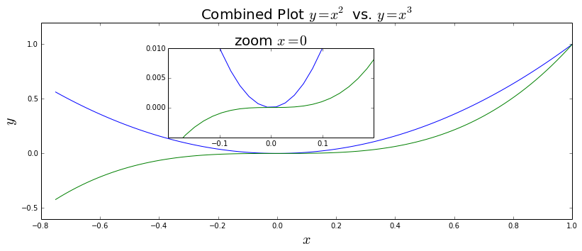

```python
#CustomPlot()
font_size = 20
figsize(11.5, 5)
fig, ax = plt.subplots()

ax.plot(xx, xx**2, xx, xx**3)
ax.set_title(r"Combined Plot $y=x^2$ vs. $y=x^3$", fontsize = font_size)
ax.set_xlabel(r'$x$', fontsize = font_size)
ax.set_ylabel(r'$y$', fontsize = font_size)
fig.tight_layout()
# inset
inset_ax = fig.add_axes([0.29, 0.45, 0.35, 0.35]) # X, Y, width, height
inset_ax.plot(xx, xx**2, xx, xx**3)
inset_ax.set_title(r'zoom $x=0$',fontsize=font_size)
# set axis range
inset_ax.set_xlim(-.2, .2)
inset_ax.set_ylim(-.005, .01)
# set axis tick locations
inset_ax.set_yticks([0, 0.005, 0.01])
inset_ax.set_xticks([-0.1,0,.1]);
show()
```

## Adding text to a plot

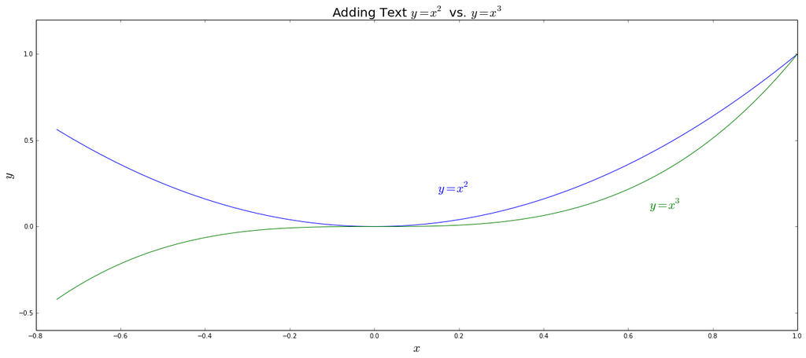

```python
#CustomPlot()
figsize(22, 9)
font_size = 20
fig, ax = plt.subplots()
ax.plot(xx, xx**2, xx, xx**3)
ax.set_xlabel(r'$x$', fontsize = font_size)
ax.set_ylabel(r'$y$', fontsize = font_size)
ax.set_title(r"Adding Text $y=x^2$ vs. $y=x^3$", fontsize = font_size)
ax.text(0.15, 0.2, r"$y=x^2$", fontsize=font_size, color="blue")
ax.text(0.65, 0.1, r"$y=x^3$", fontsize=font_size, color="green");
```

## xkcd style plotting

- [matplolib v1.3](http://matplotlib.org/xkcd/examples/showcase/xkcd.html) now includes a setting to make plots resemble xkcd styles.

[figure not shown]

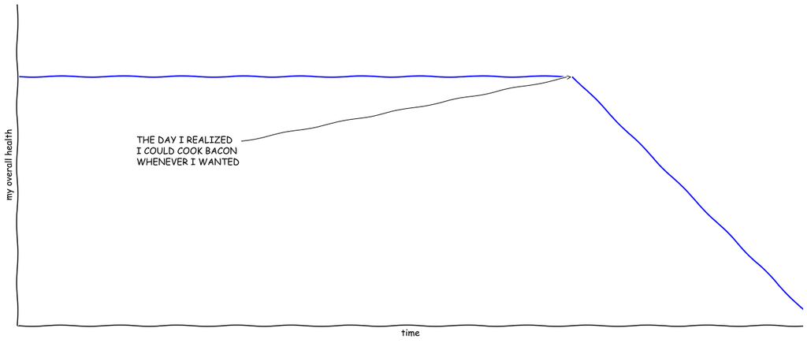

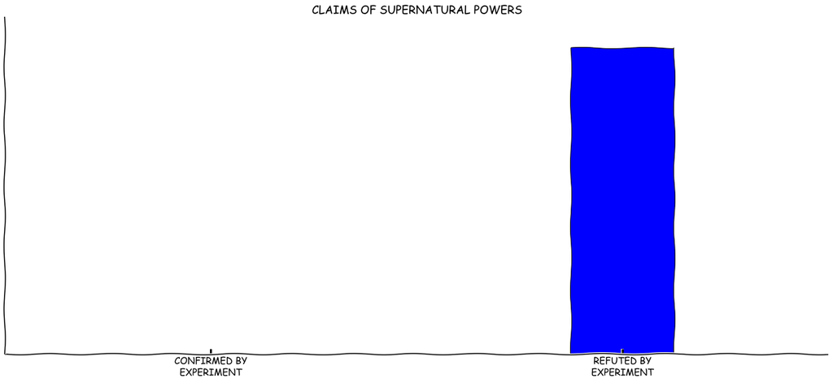

```python
from matplotlib import pyplot as plt
import numpy as np


with plt.xkcd():
    fig = plt.figure()
    ax = fig.add_subplot(1, 1, 1)
    ax.spines['right'].set_color('none')
    ax.spines['top'].set_color('none')
    plt.xticks([])
    plt.yticks([])
    ax.set_ylim([-30, 10])

    data = np.ones(100)
    data[70:] -= np.arange(30)

    plt.annotate(
        'THE DAY I REALIZED\nI COULD COOK BACON\nWHENEVER I WANTED',
        xy=(70, 1), arrowprops=dict(arrowstyle='->'), xytext=(15, -10))

    plt.plot(data)

    plt.xlabel('time')
    plt.ylabel('my overall health')

    fig = plt.figure()
    ax = fig.add_subplot(1, 1, 1)
    ax.bar([-0.125, 1.0-0.125], [0, 100], 0.25)
    ax.spines['right'].set_color('none')
    ax.spines['top'].set_color('none')
    ax.xaxis.set_ticks_position('bottom')
    ax.set_xticks([0, 1])
    ax.set_xlim([-0.5, 1.5])
    ax.set_ylim([0, 110])
    ax.set_xticklabels(['CONFIRMED BY\nEXPERIMENT', 'REFUTED BY\nEXPERIMENT'])
    plt.yticks([])

    plt.title("CLAIMS OF SUPERNATURAL POWERS")

    plt.show()
```

## Symbolic math using SymPy

- SymPy is a Python library for symbolic mathematics.
- It aims to become a full-featured computer algebra system (CAS) while keeping the code as simple as possible in order to be comprehensible and easily extensible.
- SymPy is written entirely in Python and does not require any external libraries.

[figure not shown]

```python
from sympy import *
init_printing(use_latex=True)
from sympy import solve
x = Symbol('x')
y = Symbol('y')
series(exp(x), x, 1, 5)
```

$$e + e x + \frac{e x^{2}}{2} + \frac{e x^{3}}{6} + \frac{e x^{4}}{24} + \mathcal{O}\left(x^{5}\right)$$

```python
eq = ((x+y)**2 * (x+1))
eq
```

$$\left(x + 1\right) \left(x + y\right)^{2}$$

```python
solve(eq)
```

$$\begin{bmatrix}\begin{Bmatrix}x : -1\end{Bmatrix}, & \begin{Bmatrix}x : - y\end{Bmatrix}\end{bmatrix}$$

```python
a = 1/x + (x*sin(x) - 1)/x
a
```

$$\frac{1}{x} \left(x \sin{\left (x \right )} - 1\right) + \frac{1}{x}$$

```python
simplify(a)
```

$$\sin{\left (x \right )}$$

```python
integrate(x**2 * exp(x) * cos(x), x)
```

$$\frac{x^{2} e^{x}}{2} \sin{\left (x \right )} + \frac{x^{2} e^{x}}{2} \cos{\left (x \right )} - x e^{x} \sin{\left (x \right )} + \frac{e^{x}}{2} \sin{\left (x \right )} - \frac{e^{x}}{2} \cos{\left (x \right )}$$

## Data Analysis Using the Pandas Library

[figure not shown]

- pandas is a Python package providing fast, flexible, and expressive data structures designed to make working with “relational” or “labeled” data both easy and intuitive
- The two primary data structures of pandas
  - Series (1-dimensional) and
  - DataFrame (2-dimensional) handle the vast majority of typical use cases in finance, statistics, social science, and many areas of engineering.
- For R users, DataFrame provides everything that R’s data.frame provides.
- pandas is built on top of NumPy and is intended to integrate well within a scientific computing environment with many other 3rd party libraries.

```python
from pandas import DataFrame, read_csv

Cape_Weather = DataFrame( read_csv('CapeTown_2009_Temperatures.csv' ))
Cape_Weather.head(14)
```

|  | high | low | radiation |
| --- | --- | --- | --- |
| 0 | 25 | 16 | 29.0 |
| 1 | 23 | 15 | 25.7 |
| 2 | 25 | 15 | 21.5 |
| 3 | 26 | 16 | 15.2 |
| 4 | 26 | 17 | 10.8 |
| 5 | 26 | 17 | 9.1 |
| 6 | 25 | 17 | 9.7 |
| 7 | 25 | 17 | 12.5 |
| 8 | 23 | 16 | 17.5 |
| 9 | 25 | 15 | 22.4 |
| 10 | 30 | 16 | 27.3 |
| 11 | 26 | 15 | 29.1 |
| 12 | 25 | 17 | NaN |
| 13 | 23 | 16 | NaN |

14 rows × 3 columns

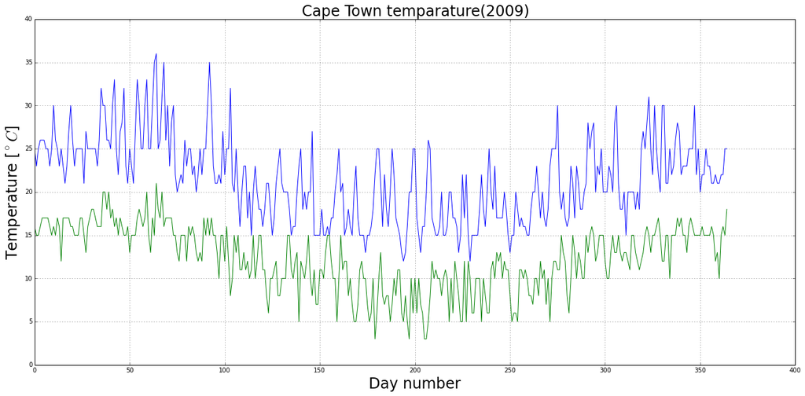

```python
#CustomPlot()
figsize(22, 10)
font_size = 24
title('Cape Town temparature(2009)',fontsize = font_size)
xlabel('Day number',fontsize = font_size)
ylabel(r'Temperature [$^\circ C$] ',fontsize = font_size)
Cape_Weather.high.plot()
Cape_Weather.low.plot()
show()
```

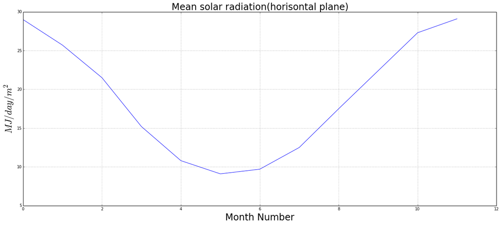

```python
#CustomPlot()
figsize(22, 9)
font_size = 24
title( 'Mean solar radiation(horisontal plane)', fontsize=font_size)
xlabel('Month Number', fontsize = font_size)
ylabel(r'$MJ / day / m^2$',fontsize = font_size)
Cape_Weather.radiation.plot()
show()
```

```python
# lets look at a proxy for heating degree and cooling degree days
level = 25
print 'Days warmer than', level, '=', Cape_Weather[ Cape_Weather['high'] > level  ].count()['high']
print 'Days cooler than', level, '=', Cape_Weather[ Cape_Weather['high'] <= level ].count()['high']
```

```
Days warmer than 25 = 59
Days cooler than 25 = 306
```

```python
# Basic descriptive statistics
print Cape_Weather.describe()
```

```
             high         low  radiation
count  365.000000  365.000000   12.00000
mean    21.545205   12.290411   19.15000
std      4.764943    3.738431    7.65156
min     12.000000    3.000000    9.10000
25%     18.000000   10.000000   12.07500
50%     21.000000   12.000000   19.50000
75%     25.000000   15.000000   26.10000
max     36.000000   21.000000   29.10000

[8 rows x 3 columns]
```

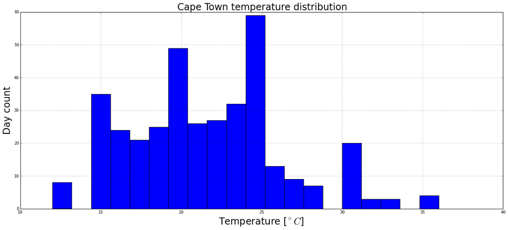

```python
#CustomPlot()
figsize(22, 9)
font_size = 24
title('Cape Town temperature distribution', fontsize=font_size)
ylabel('Day count',fontsize = font_size)
xlabel(r'Temperature [$^\circ C $] ',fontsize = font_size)
Cape_Weather['high'].hist(bins=20)
show()
```

## Typesetting

### LaTex

- LaTex is rendered using the mathjax.js JavaScript library

```python
from IPython.display import Math
Math(r'F(k) = \int_{-\infty}^{\infty} f(x) e^{2\pi i k} dx')
```

$$F(k) = \int_{-\infty}^{\infty} f(x) e^{2\pi i k} dx$$

```python
from IPython.display import Latex
Latex(r"""\begin{eqnarray}
\nabla \times \vec{\mathbf{B}} -\, \frac1c\, \frac{\partial\vec{\mathbf{E}}}{\partial t} & = \frac{4\pi}{c}\vec{\mathbf{j}} \\
\nabla \cdot \vec{\mathbf{E}} & = 4 \pi \rho \\
\nabla \times \vec{\mathbf{E}}\, +\, \frac1c\, \frac{\partial\vec{\mathbf{B}}}{\partial t} & = \vec{\mathbf{0}} \\
\nabla \cdot \vec{\mathbf{B}} & = 0
\end{eqnarray}""")
```

\begin{eqnarray} \nabla \times \vec{\mathbf{B}} -\, \frac1c\, \frac{\partial\vec{\mathbf{E}}}{\partial t} & = \frac{4\pi}{c}\vec{\mathbf{j}} \\ \nabla \cdot \vec{\mathbf{E}} & = 4 \pi \rho \\ \nabla \times \vec{\mathbf{E}}\, +\, \frac1c\, \frac{\partial\vec{\mathbf{B}}}{\partial t} & = \vec{\mathbf{0}} \\ \nabla \cdot \vec{\mathbf{B}} & = 0 \end{eqnarray}

## Saving a Gist

- It is possible to save specific lines of code to a GitHub gist.
- This is achieved with the `%pastebin` magic as demonstrated below.
- This makes sharing code easy!

```python
%pastebin "cell one" 0-10
```

```
u'https://gist.github.com/b8f4d582d569e9ada3c7'
```

## Connect to this kernel remotely

- Using the *%connect_info* magic you can obtain the connection info to connect to this workbook from another IPython console or qtconsole using :
  - *ipython qtconsole --existing*
- Using the port, signature and key you can also connect to a remote IPython kernel via SSH

```python
%connect_info
# lets connect to this kernel using the command "ipython qtconsole --existing"
```

```
{
  "stdin_port": 55868,
  "ip": "127.0.0.1",
  "control_port": 55869,
  "hb_port": 55870,
  "signature_scheme": "hmac-sha256",
  "key": "0730111c-2113-40b2-af7d-852ffb8fa3a1",
  "shell_port": 55866,
  "transport": "tcp",
  "iopub_port": 55867
}

Paste the above JSON into a file, and connect with:
    $> ipython <app> --existing <file>
or, if you are local, you can connect with just:
    $> ipython <app> --existing kernel-80787d64-3206-48d6-ae65-50b9bd7e8c24.json
or even just:
    $> ipython <app> --existing
if this is the most recent IPython session you have started.
```

# Adding Interactivity

- IPython includes an architecture for interactive widgets
- Ties together Python code running in the kernel and JavaScript/HTML/CSS in the browser
- These widgets enable users to explore their code and data interactively

```python
from IPython.html.widgets import interact
import matplotlib.pyplot as plt
import networkx as nx

# wrap a few graph generation functions so they have the same signature

def random_lobster(n, m, k, p):
    return nx.random_lobster(n, p, p / m)

def powerlaw_cluster(n, m, k, p):
    return nx.powerlaw_cluster_graph(n, m, p)

def erdos_renyi(n, m, k, p):
    return nx.erdos_renyi_graph(n, p)

def newman_watts_strogatz(n, m, k, p):
    return nx.newman_watts_strogatz_graph(n, k, p)

def plot_random_graph(n, m, k, p, generator):
    g = generator(n, m, k, p)
    nx.draw(g)
    plt.show()
```

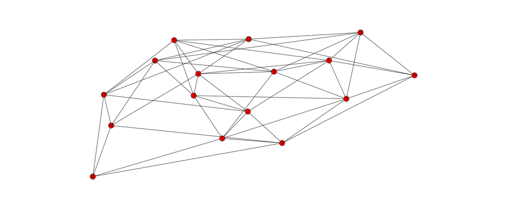

```python
#static
plot_random_graph( 16, 5, 5, 0.449, newman_watts_strogatz)
```

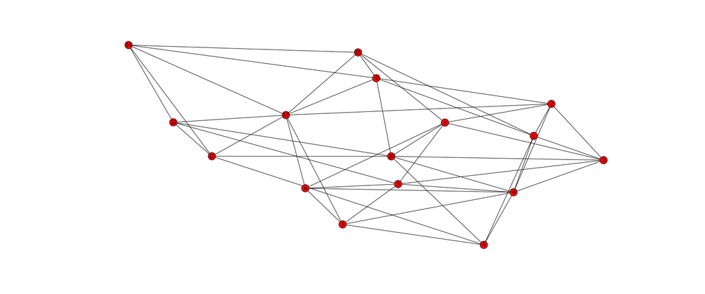

```python
interact(
        plot_random_graph, n=(2,30), m=(1,10), k=(1,10), p=(0.0, 1.0, 0.001),
        generator={'lobster': random_lobster,
                   'power law': powerlaw_cluster,
                   'Newman-Watts-Strogatz': newman_watts_strogatz,
                   u'Erdős-Rényi': erdos_renyi,
                   });
```

```python
from IPython.html.widgets import interact
import matplotlib.pyplot as plt
import numpy as np

%matplotlib inline

np.random.seed(0)
x, y = np.random.normal(size=(2, 100))
s, c = np.random.random(size=(2, 100))

def draw_scatter(size=100, cmap='jet', alpha=1.0):
    fig, ax = plt.subplots(figsize=(20, 8))
    points = ax.scatter(x, y, s=size*s, c=c, alpha=alpha, cmap=cmap)
    fig.colorbar(points, ax=ax)
    return fig

colormaps = sorted(m for m in plt.cm.datad if not m.endswith("_r"))
```

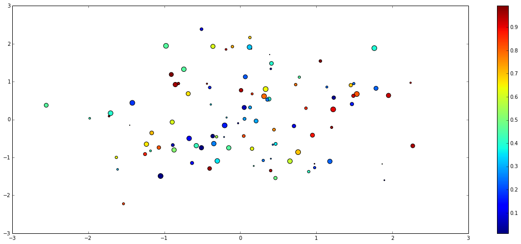

```python
interact(
            draw_scatter, size=[0, 2000], alpha=[0.0, 1.0], cmap=colormaps
        );
```

# Exploring Beat Frequencies using the Audio Object

- This example uses the Audio object and Matplotlib to explore the phenomenon of beat frequencies.

```python
%matplotlib inline
import matplotlib.pyplot as plt
import numpy as np

from IPython.html.widgets import interactive
from IPython.display import Audio, display
import numpy as np

def beat_freq(f1=220.0, f2=224.0):
    max_time = 3
    rate = 8000
    times = np.linspace(0,max_time,rate*max_time)
    signal = np.sin(2*np.pi*f1*times) + np.sin(2*np.pi*f2*times)
    print(f1, f2, abs(f1-f2))
    display(Audio(data=signal, rate=rate))
    return signal
```

```python
v = interactive(beat_freq, f1=(200.0,300.0), f2=(200.0,300.0))
display(v)
```

```
(220.0, 224.0, 4.0)
```

[interactive chart not shown]

## Lorenz System of Differential Equations

- Also example to link to other notebooks
- Click Lorenz Differential Equations

# Machine Learning with Sci-Kit Learn

[figure not shown]

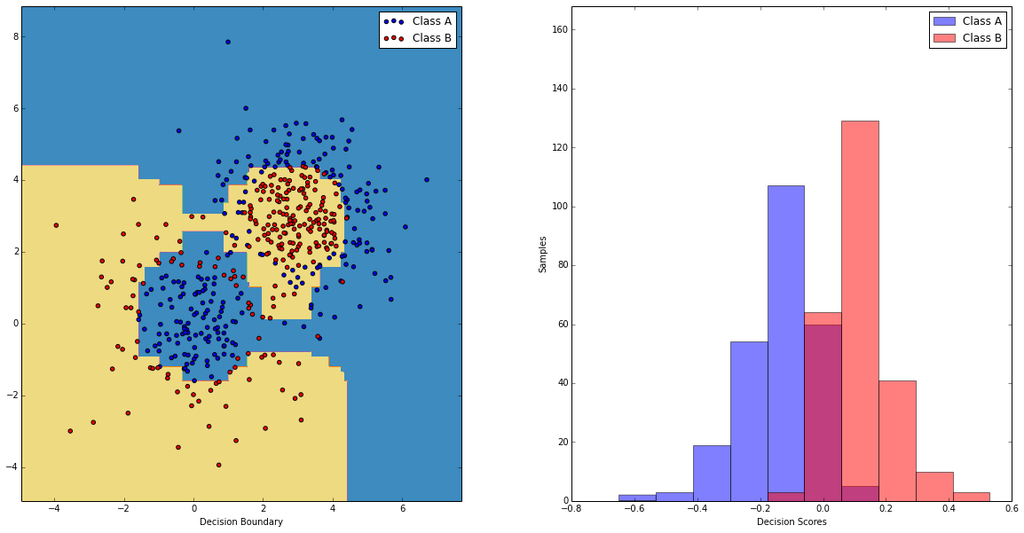

```python
import pylab as pl
import numpy as np

from sklearn.ensemble import AdaBoostClassifier
from sklearn.tree import DecisionTreeClassifier
from sklearn.datasets import make_gaussian_quantiles


# Construct dataset
X1, y1 = make_gaussian_quantiles(cov=2.,
                                 n_samples=200, n_features=2,
                                 n_classes=2, random_state=1)
X2, y2 = make_gaussian_quantiles(mean=(3, 3), cov=1.5,
                                 n_samples=300, n_features=2,
                                 n_classes=2, random_state=1)
#Training Samples
X = np.concatenate((X1, X2))

#Training Target
y = np.concatenate((y1, - y2 + 1))

# Create and fit an AdaBoosted decision tree
bdt = AdaBoostClassifier(
                          DecisionTreeClassifier( max_depth=1),
                                                  algorithm="SAMME",
                                                  n_estimators=200
                        )

bdt.fit(X, y)

plot_colors = "br"
plot_step = 0.02
class_names = "AB"

pl.figure(figsize=(20, 10))

# Plot the decision boundaries
pl.subplot(121)
x_min, x_max = X[:, 0].min() - 1, X[:, 0].max() + 1
y_min, y_max = X[:, 1].min() - 1, X[:, 1].max() + 1
xx, yy = np.meshgrid(np.arange(x_min, x_max, plot_step),
                     np.arange(y_min, y_max, plot_step))

Z = bdt.predict(np.c_[xx.ravel(), yy.ravel()])

Z = Z.reshape(xx.shape)
cs = pl.contourf(xx, yy, Z, cmap=pl.cm.Paired)
pl.axis("tight")

# Plot the training points
for i, n, c in zip(range(2), class_names, plot_colors):
    idx = np.where(y == i)
    pl.scatter(X[idx, 0], X[idx, 1],
               c=c, cmap=pl.cm.Paired,
               label="Class %s" % n)
pl.xlim(x_min, x_max)
pl.ylim(y_min, y_max)
pl.legend(loc='upper right')
pl.xlabel("Decision Boundary")

# Plot the two-class decision scores
twoclass_output = bdt.decision_function(X)
plot_range = (twoclass_output.min(), twoclass_output.max())
pl.subplot(122)
for i, n, c in zip(range(2), class_names, plot_colors):
    pl.hist(twoclass_output[y == i],
            bins=10,
            range=plot_range,
            facecolor=c,
            label='Class %s' % n,
            alpha=.5)
x1, x2, y1, y2 = pl.axis()
pl.axis((x1, x2, y1, y2 * 1.2))
pl.legend(loc='upper right')
pl.ylabel('Samples')
pl.xlabel('Decision Scores')
pl.subplots_adjust(wspace=0.25)
pl.show()
```

## Publishing your Work

- Ability to convert an .ipynb notebook document file into various static formats.
- Currently, nbconvert is provided as a command line tool, run as a script using IPython.

This page is converted and published to the following formats using this tool:

- HTML
- PDF (the PDF is created using wkhtml2pdf that takes the html file as an input)
- LATEX
- Reveal.js slideshow

```python
!ipython nbconvert csir_ipython.ipynb --to slides --post serve
```

```
[NbConvertApp] Using existing profile dir: u'/Users/tobie/.ipython/profile_default'
[NbConvertApp] Converting notebook csir_ipython.ipynb to slides
[NbConvertApp] Support files will be in csir_ipython_files/
[NbConvertApp] Loaded template slides_reveal.tpl
[NbConvertApp] Writing 1960230 bytes to csir_ipython.slides.html
[NbConvertApp] Redirecting reveal.js requests to https://cdn.jsdelivr.net/reveal.js/2.5.0
Serving your slides at http://127.0.0.1:8000/csir_ipython.slides.html
Use Control-C to stop this server
WARNING:tornado.access:404 GET /custom.css (127.0.0.1) 1.65ms
WARNING:tornado.access:404 GET /favicon.ico (127.0.0.1) 0.99ms
^C
Interrupted
```

```python
!ipython nbconvert csir_ipython.ipynb --to html --post serve
```

```
[NbConvertApp] Using existing profile dir: u'/Users/tobie/.ipython/profile_default'
[NbConvertApp] Converting notebook csir_ipython.ipynb to html
[NbConvertApp] Support files will be in csir_ipython_files/
[NbConvertApp] Loaded template full.tpl
[NbConvertApp] Writing 1953559 bytes to csir_ipython.html
[NbConvertApp] Redirecting reveal.js requests to https://cdn.jsdelivr.net/reveal.js/2.5.0
Serving your slides at http://127.0.0.1:8000/csir_ipython.html
Use Control-C to stop this server
WARNING:tornado.access:404 GET /custom.css (127.0.0.1) 0.75ms
^C
Interrupted
```

# Writing Books!

- Need internet connection but check out
- [Probabilistic-Programming-and-Bayesian-Methods-for-Hackers](http://camdavidsonpilon.github.io/Probabilistic-Programming-and-Bayesian-Methods-for-Hackers/)

# Want to Learn More

- Basic one day Python course (12 July, Meetup.com)
- Upcoming Open Source Data Science course
- Or tailor made...

# THANK YOU FOR YOUR TIME

- some further interesting websites linked below
- Presented at CSIR, 30 May 2014
- [Anaconda Download Links](http://www.insightstack.co.za/downloads/)
- Download the notebook and run **ipyton notebook** in the directory with this file
- Request re Image processing. Have a look at:
  - [Open CV](http://opencv.org/) with the [Python bindings](https://code.google.com/p/pyopencv/)
  - [pillow](https://github.com/python-imaging/Pillow)
- Examples of running other languages in the notebook
  - [IRuby](http://nbviewer.ipython.org/github/minad/iruby/blob/master/IRuby-Example.ipynb)
  - [Julia](http://nbviewer.ipython.org/github/JuliaLang/IJulia.jl/blob/master/python/doc/JuliaMagic.ipynb)
  - [Octave](http://nbviewer.ipython.org/github/ipython/ipython/blob/d835d46dcc50043971b4a9915398bad1b5d63648/docs/examples/notebooks/octavemagic_extension.ipynb)
  - [R](http://nbviewer.ipython.org/github/ipython/ipython/blob/3607712653c66d63e0d7f13f073bde8c0f209ba8/docs/examples/notebooks/rmagic_extension.ipynb)
  - [js](http://nbviewer.ipython.org/gist/minrk/5632595)

```python
website('http://www.eon.co.za/index.php/our-services-main/our-services/business-analytics', width=1000, height=600)
```

http://www.eon.co.za/index.php/our-services-main/our-services/business-analytics

[interactive chart not shown]

```python
website('www.insightstack.co.za', width=1000, height=600)
```

www.insightstack.co.za

[interactive chart not shown]

```python
website("http://www.pyzo.org/python_vs_matlab.html", width=1000, height=600)
```

http://www.pyzo.org/python_vs_matlab.html

[interactive chart not shown]

```python
website('https://www.pythonanywhere.com/try-ipython/',width=1000, height=600)
```

https://www.pythonanywhere.com/try-ipython/

[interactive chart not shown]